# Test Harvest Control Rule with a Butterfish-like stock

Sarah Gaichas

2026-08-26

# Code modified from the SPASM.MSE vignettes

Vignettes found [here](https://lichengxue.github.io/SPASAM.MSE/index.html)

Starting point is this one https://lichengxue.github.io/SPASAM.MSE/Use-Actual-Stock-Assessment.html

And modifying to test the addition of the MAFMC risk policy and ABC HCR that I added to my own version of `SPASAM.MSE::advice_fn()`

## Operating model setup

### Basic information

This is all modified for butterfish

The 2022 butterfish RT models are posted online in the SASI portal [here](https://apps-nefsc.fisheries.noaa.gov/saw/sasi_files.php?year=2022&species_id=16&stock_id=6&review_type_id=5&info_type_id=3&map_type_id=&filename=WHAM_models.zip).

Chuck kindly sent the 2024 MT outputs when I requested them; and converted them to multi-wham, which I think made all the difference in getting this up and running. A day or two was spent trying to make the RT model work but it kept blowing up because WHAM 2.0 is very different from WHAM 1.0

Read in the models (2024 MT in WHAM 2.0)

```r
# buttermods <- readRDS(here::here("./assessments/Butterfish2022_WHAM_models/mods.rds"))
#
# buttermods[[1]]$model_name
# buttermods[[2]]$model_name
# buttermods[[3]]$model_name
#
# base2022 <- buttermods[[1]] # ASAP in WHAM
# recdev2022 <- buttermods[[2]] # This with only rec RE may be closer to the example from the vignette
# NAAmod2022 <- buttermods[[3]] # This is the preferred model with NAA RE

buttermod <- readRDS(here::here("./assessments/Butterfish2022_WHAM_models/naa5_2024MT_multiwham.rds"))

buttermod$wham_version
```

```
## [1] "2.0.0.9004 / Github (timjmiller/wham@7a3c67c4e0a11338852056956d21139d8b932303)"
```

Can I use these as a basis? Follow https://lichengxue.github.io/SPASAM.MSE/Use-Actual-Stock-Assessment.html

Need to figure out how to read in only the inputs, may be possible using code in https://timjmiller.github.io/wham/articles/ex13_no_ASAP.html

Global settings

```r
input_hist <- buttermod$input #prepare_wham_input(gb_dat)
input      <- buttermod$input #prepare_wham_input(gb_dat)

n_stocks  <- 1L
n_regions <- 1L
n_ages    <- 5L # NAAmod2022$input$data$n_ages is 5
n_indices <- 6L # NAAmod2022$input$data$n_indices is 6
n_fleets  <- 1L # NAAmod2022$input$data$n_fleets is 1
n_seasons <- 1L

# butterfish RT assessment start and end data years NAAmod2022$years, updated for 2024 MT
year_start  <- 1989L
year_end    <- 2023L
MSE_years   <- 9L # 3 3yr assessment cycles

n_hist_years <- year_end - year_start + 1L
n_proj_years <- n_hist_years + MSE_years

base_years      <- year_start:year_end
assess_interval <- 3L

stopifnot(MSE_years %% assess_interval == 0L)

assess_years <- seq(
  tail(base_years, 1),
  year_end + MSE_years - assess_interval,
  by = assess_interval
)

# Historical period is fixed.
# Only years from first_free_year onward are allowed to vary.
first_free_year <- 36L # year after last historical year
```

Historical model

I don’t need most of this because I want to use the original assessment directly. Kept the code blocks but mostly commented out below aside from variables used later

Bio inputs

```r
# user_maturity_hist <- array(NA_real_, dim = c(n_stocks, n_hist_years, n_ages))
# user_maturity_hist[, 1:n_hist_years, ] <- input$data$mature
#
# user_waa_hist <- list()
# user_waa_hist$waa <- array(NA_real_, dim = c(2, n_hist_years, n_ages))
# user_waa_hist$waa[, 1:n_hist_years, ] <- input$data$waa
# user_waa_hist$waa_pointer_fleets   <- input$data$waa_pointer_fleets
# user_waa_hist$waa_pointer_indices  <- input$data$waa_pointer_indices[-1] #there are 6 indices and 7 here?
# user_waa_hist$waa_pointer_totcatch <- input$data$waa_pointer_totcatch
# user_waa_hist$waa_pointer_ssb      <- input$data$waa_pointer_ssb
# user_waa_hist$waa_pointer_M        <- input$data$waa_pointer_M

fracyr_spawn <- input$asap3[[1]]$fracyr_spawn #gb_dat[[1]]$dat$fracyr_spawn
```

Catch and index observation settings

```r
# catch_info_hist <- list(
#   catch_cv      = 0.3,
#   catch_Neff    = 41,
#   use_agg_catch = 1,
#   use_catch_paa = 1
# )
#
# index_info_hist <- list(
#   index_cv        = c(0.4699923, 0.5389348, 0.6166915, 0.5313571, 0.7573711, 0.3517145), #rep(0.5, n_indices),
#   index_Neff      = c(10.967742,  4.838710,  1.677419,  4.967742,  1.064516, 0.000000), #rep(25, n_indices),
#   fracyr_indices  = c(0.75, 0.75, 0.75, 0.25, 0.3333333, 0.75),
#   q               = rep(0.2, n_indices),
#   use_indices     = rep(1, n_indices),
#   use_index_paa   = rep(1, n_indices),
#   units_indices   = rep(2, n_indices),
#   units_index_paa = rep(2, n_indices)
# )
```

Alternatively take from the assessment? Try if not using the full fitted assessment, not necessary here

```r
# from  https://timjmiller.github.io/wham/articles/ex13_no_ASAP.html

# basic_info_hist <- list(
#     n_stocks = 1L,
#     n_seasons = 1L,
#     n_fleets = 1L,
#     ages = 1:input$data$n_ages,
#     n_fleets = input$data$n_fleets,
#     fracyr_SSB = cbind(input$data$fracyr_SSB), #(n_years x n_stocks)
#     maturity = input$data$mature, #(n_stocks x n_years x n_ages)
#     years = as.integer(input$years), #(n_years)
#     waa = input$data$waa, #(any no. x n_years x n_ages)
#     waa_pointer_ssb = input$data$waa_pointer_ssb, #(n_stocks)
#     spawn_regions = 1, #(n_stocks)
#     spawn_seasons = 1 #(n_stocks)
# )
#
# catch_info_hist <- list(
#     n_fleets = NCOL(input$data$agg_catch), #(n_fleets)
#     agg_catch = cbind(input$data$agg_catch), #(n_years x n_fleets)
#     agg_catch_cv = cbind(sqrt(exp(input$data$agg_catch_sigma^2) - 1)), #(n_years x n_fleets)
#     catch_paa = input$data$catch_paa, #(n_fleets x n_years x n_ages)
#     use_catch_paa = cbind(input$data$use_catch_paa), #(n_years x n_fleets), 0: don't use, 1: use
#     catch_Neff = cbind(input$data$catch_Neff), #(n_years x n_fleets)
#     selblock_pointer_fleets = cbind(input$data$selblock_pointer_fleets), #(n_years x n_fleets)
#     waa_pointer_fleets = input$data$waa_pointer_fleets, #(n_fleets)
#     fleet_regions = rep(1,input$data$n_fleets) #(n_fleets)
# )
#
# index_info_hist <- list(
#     n_indices = NCOL(input$data$agg_indices),
#     agg_indices = cbind(input$data$agg_indices), #(n_years x n_indices)
#     units_indices = input$data$units_indices, #(n_indices) 1: biomass 2: numbers
#     units_index_paa = input$data$units_index_paa, #(n_indices) 1: biomass 2: numbers
#     agg_index_cv = cbind(sqrt(exp(input$data$agg_index_sigma^2) - 1)), #(n_years x n_indices)
#     index_Neff = cbind(input$data$index_Neff), #(n_years x n_indices)
#     fracyr_indices = cbind(input$data$fracyr_indices), #(n_years x n_indices)
#     use_indices = cbind(input$data$use_indices), #(n_years x n_indices)
#     use_index_paa = cbind(input$data$use_index_paa),  #(n_years x n_indices)
#     index_paa = input$data$index_paa,  #(n_indices x n_years x n_ages)
#     selblock_pointer_indices = cbind(input$data$selblock_pointer_indices), #(n_years x n_indices)
#     waa_pointer_indices = input$data$waa_pointer_indices, #(n_indices)
#     index_regions = rep(1,input$data$n_indices) #(n_indices)
# )
```

Build the model scaffold

```r
# info_hist <- SPASAM.MSE::generate_basic_info(
#   n_stocks = n_stocks,
#   n_regions = n_regions,
#   n_indices = n_indices,
#   n_fleets = n_fleets,
#   n_seasons = n_seasons,
#   base.years = year_start:year_end,
#   n_feedback_years = 0L,
#   n_ages = n_ages,
#   catch_info = catch_info_hist,
#   index_info = index_info_hist,
#   user_waa = user_waa_hist,
#   user_maturity = user_maturity_hist,
#   fracyr_spawn = fracyr_spawn,
#   life_history = "short"
# )
#
# #basic_info_hist     <- info_hist$basic_info
# catch_info_use_hist <- info_hist$catch_info
# index_info_use_hist <- info_hist$index_info
# F_info_hist         <- info_hist$F
#
# catch_info_use_hist$agg_catch[1:n_hist_years, ]     <- input$data$agg_catch
# catch_info_use_hist$catch_paa[, 1:n_hist_years, ]   <- input$data$catch_paa
# index_info_use_hist$agg_indices[1:n_hist_years, ]   <- input$data$agg_indices
# index_info_use_hist$index_paa[, 1:n_hist_years, ]   <- input$data$index_paa
# index_info_use_hist$use_indices[1:n_hist_years, ]   <- input$data$use_indices
# index_info_use_hist$use_index_paa[1:n_hist_years, ] <- input$data$use_index_paa
```

Selectivity, M, etc

I started redimensioning this but stopped because I’m just reading in the original butterfish model

```r
# sel_hist <- list(
#   model = c("age-specific", "logistic", "logistic", "logistic", "logistic", "logistic", "logistic"),
#   re    = c("ar1_y", "none", "none", "none", "none", "none", "none"),
#   initial_pars = list(
#     c(0.1, 0.25, 0.5, 1, 1),
#     c(2, 0.3),
#     c(2, 0.3),
#     c(2, 0.3),
#     c(2, 0.3),
#     c(2, 0.3),
#     c(2, 0.3)
#
#   ),
#   fix_pars = list(c(4:6), NULL, NULL, NULL, NULL, NULL, NULL)
# )
#
# M_hist <- list(
#   model = "constant",
#   initial_means = array(
#     c(0.57, 0.33, 0.26, 0.23, 0.22),
#     dim = c(n_stocks, n_regions, n_ages)
#   )
# )
#
# sigma_vals_hist <- array(0, dim = c(n_stocks, n_regions, n_ages))
# sigma_vals_hist[, , 1] <- 0.5
#
# NAA_re_hist <- list(
#   N1_model      = rep("equilibrium", n_stocks),
#   sigma         = rep("rec", n_stocks),
#   cor           = rep("iid", n_stocks),
#   recruit_model = 2,
#   sigma_vals    = sigma_vals_hist
# )
```

Prep and fit historical model, not doing this just reading in 2024 MT model in WHAM 2.0

```r
# input_histfit <- prepare_wham_input(
#   basic_info  = basic_info_hist,
#   selectivity = sel_hist,
#   M           = M_hist,
#   NAA_re      = NAA_re_hist,
#   catch_info  = catch_info_use_hist,
#   index_info  = index_info_use_hist,
#   F           = F_info_hist,
#   age_comp    = "logistic-normal-pool0"
# )
#
# input_histfit <- update_waa(input_histfit, waa_info = info_hist$par_inputs$user_waa)
#
# input_e <- input #prepare_wham_input(gb_dat)
# input_histfit$data$agg_index_sigma[1:n_hist_years, ] <- input_e$data$agg_index_sigma
# input_histfit$data$use_indices[1:n_hist_years, ]     <- input_e$data$use_indices
# input_histfit$data$use_index_paa[1:n_hist_years, ]   <- input_e$data$use_index_paa
#
# generate_remove_years <- function(mat) {
#   lz <- lapply(seq_len(ncol(mat)), function(j) which(mat[, j] == 0))
#   if (all(lengths(lz) == 0)) return(NULL)
#   max_rows <- max(sapply(lz, length))
#   out <- matrix(NA_integer_, nrow = max_rows, ncol = length(lz))
#   for (j in seq_along(lz)) {
#     if (length(lz[[j]])) out[seq_along(lz[[j]]), j] <- lz[[j]]
#   }
#   out
# }
#
# remove_agg_years1 <- generate_remove_years(input_e$data$use_indices)
# remove_paa_years1 <- generate_remove_years(input_e$data$use_index_paa)
#
# input_histfit <- update_input_index_info(
#   input_histfit,
#   agg_index_sigma = input_histfit$data$agg_index_sigma,
#   index_Neff      = input_histfit$data$index_Neff,
#   remove_agg = TRUE,
#   remove_agg_pointer = 1:3,
#   remove_agg_years = remove_agg_years1,
#   remove_paa = TRUE,
#   remove_paa_pointer = 1:3,
#   remove_paa_years = remove_paa_years1
# )

# om_file <- system.file("extdata", "OM.RDS", package = "SPASAM.MSE")
#
# if (file.exists(om_file)) {
#
#   OM <- readRDS(om_file)
#
# } else {
#
#.  # This blows up every time
  # OM <- fit_wham(
  #   input_histfit,
  #   do.fit = TRUE,
  #   do.brps = TRUE,
  #   do.retro = FALSE,
  #   do.osa = FALSE,
  #   MakeADFun.silent = TRUE
  # )
#
#   saveRDS(OM, file.path(tempdir(), "OM.RDS"))
#
# }

# could the initial OM not be the fitted model?

OM <- buttermod

check_convergence(OM)
```

```
## stats:nlminb thinks the model has converged: mod$opt$convergence == 0
```

```
## Maximum gradient component:7.24e-13
```

```
## Max gradient parameter:catch_paa_pars
```

```
## TMB:sdreport() was performed successfully for this model
```

### Extend assessment to do free projections

Now try using the original model as is and extending to projections. Go back to Cheng’s code (adjusted some dims here (waa from 5 in the example to 8))

```r
user_maturity <- array(NA_real_, dim = c(n_stocks, n_proj_years, n_ages))
user_maturity[, 1:n_hist_years, ] <- OM$input$data$mature[, 1:n_hist_years, ]
for (iy in (n_hist_years + 1L):n_proj_years) {
  user_maturity[, iy, ] <- OM$input$data$mature[, n_hist_years, , drop = FALSE]
}

user_waa <- list()
user_waa$waa <- array(NA_real_, dim = c(8, n_proj_years, n_ages))
user_waa$waa[, 1:n_hist_years, ] <- OM$input$data$waa[, 1:n_hist_years, ]
for (iy in (n_hist_years + 1L):n_proj_years) {
  user_waa$waa[, iy, ] <- OM$input$data$waa[, n_hist_years, , drop = FALSE]
}

user_waa$waa_pointer_fleets   <- OM$input$data$waa_pointer_fleets
user_waa$waa_pointer_indices  <- OM$input$data$waa_pointer_indices
user_waa$waa_pointer_totcatch <- OM$input$data$waa_pointer_totcatch
user_waa$waa_pointer_ssb      <- OM$input$data$waa_pointer_ssb
user_waa$waa_pointer_M        <- OM$input$data$waa_pointer_M # this is null in input but gets set equal to waa_pointer_ssb anyway
# all of these get overwritten anyway, hardcoded in SPASAM.MSE::generate_basic_info
```

Catch and index

```r
# catch_info <- list(
#   catch_cv      = 0.05,
#   catch_Neff    = 50,
#   use_agg_catch = 1,
#   use_catch_paa = 1
# )
#
# index_info <- list(
#   index_cv        = rep(0.5, n_indices),
#   index_Neff      = rep(25, n_indices),
#   fracyr_indices  = c(0.25, 0.75, 0.25),
#   q               = c(2.110e-4, 2.247e-4, 2.683e-4),
#   use_indices     = rep(1, n_indices),
#   use_index_paa   = rep(1, n_indices),
#   units_indices   = rep(2, n_indices),
#   units_index_paa = rep(2, n_indices)
# )

catch_info <- list(
  catch_cv      = 0.2623537, #mean(input$data$agg_catch_sigma)
  catch_Neff    = 43, #input$data$catch_Neff
  use_agg_catch = 1,
  use_catch_paa = 1
)

index_info <- list(
  index_cv        = c(0.5010909, 0.5451420, 0.5038754, 0.5337914, 0.6915221, 0.3634754), #rep(0.5, n_indices), colMeans(input$data$agg_index_sigma)
  index_Neff      = c(20,  17,  5,  24,  3, 0), #rep(25, n_indices), took constants for each index in input$data$index_Neff
  fracyr_indices  = c(0.75, 0.75, 0.75, 0.25, 0.3333333, 0.75), #input$data$fracyr_indices
  q               = c(0.197517, 0.523248, 0.1647172, 0.464651, 0.1039347, 3.424289e-05), #rep(0.2, n_indices), OM$rep$q
  use_indices     = rep(1, n_indices),
  use_index_paa   = c(rep(1, n_indices-1), 0),
  units_indices   = rep(2, n_indices),
  units_index_paa = rep(2, n_indices)
)
```

Scaffold

```r
info <- SPASAM.MSE::generate_basic_info(
  n_stocks = n_stocks,
  n_regions = n_regions,
  n_indices = n_indices,
  n_fleets = n_fleets,
  n_seasons = n_seasons,
  base.years = year_start:year_end,
  n_feedback_years = MSE_years,
  n_ages = n_ages,
  #life_history = "short", #added; need?
  catch_info = catch_info,
  index_info = index_info,
  user_waa = user_waa,
  user_maturity = user_maturity,
  fracyr_spawn = fracyr_spawn
)
```

```
## Using user-specified WAA array. WAA can be time-varying.
```

```
##
##   --------------------
##
##   IMPORTANT!!!!
##
##   For the current version of WHAM, if WAA pointers are specified (i.e., WAA differs across fleets, indices, or stocks),
##
##   they need to be updated *after* prepare_wham_input(). Otherwise, a global WAA will be applied to all components.
##
##   --------------------
##
```

[output not shown]

```r
basic_info     <- info$basic_info
catch_info_use <- info$catch_info
index_info_use <- info$index_info

#catch_info_use$selblock_pointer_fleets[1:n_hist_years, ] <- input$data$selblock_pointer_fleets

catch_info_use$agg_catch[1:n_hist_years, ]     <- input$data$agg_catch
catch_info_use$catch_paa[, 1:n_hist_years, ]   <- input$data$catch_paa

index_info_use$agg_indices[1:n_hist_years, ]   <- input$data$agg_indices
index_info_use$index_paa[, 1:n_hist_years, ]   <- input$data$index_paa
#index_info_use$use_indices[1:n_hist_years, ]   <- input$data$use_indices #added later
#index_info_use$use_index_paa[1:n_hist_years, ] <- input$data$use_index_paa #added later
```

Initialize F

```r
F_info <- info$F
F_info$F[1:n_hist_years, ] <- OM$rep$Fbar[1:n_hist_years, drop = FALSE]
```

Selectivity, M, and process in OM

```r
sel3 <- list(
  n_selblocks = OM$input$data$n_selblocks, # added
  model = rep("age-specific", 8), #input$data$selblock_models = 1 for all
  re    = rep("none", 8), #input$data$selblock_models_re = 1 for all
  initial_pars = list( #from OM$rep$selAA
    c(0.013508, 0.1829535, 0.642894,    1, 0.532285),
    c(0.003615705, 0.06812128, 0.3757382,    1, 0.5632194),
    c(1, 0.5265157, 0.4638104, 0.102919, 0.05952474),
    c(1, 0.6590912, 0.7439251, 0.4416134, 0.09534809),
    c(1,    1, 0.0836746, 0.05080942, 0.06792671),
    c(0,    1, 0.4274524, 0.5378442, 0.2198267),
    c(0.0221619,    1,    1, 0.07488138, 0.3999979),
    c(1,    0,    0,    0,   0)
  ),
  fix_pars = list(4, 4, 1, 1, 1:2, 1:2, 2, 1:5) # fix at least one at 1 for age specific
)

# OM$input$data$selblock_pointer_fleets has selectivity years for fishery, added

M <- list(
  model = "constant",
  initial_means = array(
    c(1.278, 1.278, 1.278, 1.278, 1.278),
    dim = c(n_stocks, n_regions, n_ages)
  )
)

sigma_vals <- array(0, dim = c(n_stocks, n_regions, n_ages))
sigma_vals[, , 1] <- exp(OM$parList$log_NAA_sigma[, , 1])
sigma_vals[, , 2:n_ages] <- exp(OM$parList$log_NAA_sigma[, , 2:n_ages])

recruit_pars_use <- exp(as.numeric(OM$parList$mean_rec_pars[1, ]))

NAA_re <- list(
  N1_model      = rep("age-specific-fe", n_stocks),
  sigma         = rep("rec+1", n_stocks),
  cor           = rep("iid", n_stocks),
  recruit_model = 2,
  recruit_pars  = list(recruit_pars_use),
  sigma_vals    = sigma_vals
)
```

Now trying to make the OM

```r
# will this fix error?
# basic_info$waa_pointer_ssb <- NULL
# basic_info$waa_pointer_M <- NULL

om_input_P <- wham::prepare_wham_input(
  basic_info  = basic_info,
  selectivity = sel3,
  M           = M,
  NAA_re      = NAA_re,
  catch_info  = catch_info_use,
  index_info  = index_info_use,
  F           = F_info,
  age_comp    = "multinomial"
)
```

```
##
## --Creating input---------------------------------------------------------------------------------------------------------------------
```

```
## basic_info done
```

```
## catch done
```

```
## indices done
```

```
## WAA done
```

```
## NAA done
```

```
## q done
```

```
## selectivity done
```

```
## age_comp done
```

```
## F done
```

```
## M done
```

```
## move done
```

[output not shown]

[output cut: 42 more lines]

[output not shown]

```
## osa_obs done
```

```
## --Input Complete--------------------------------------------------------------------------------------------------------------------
```

[output not shown]

[output cut: 9 more lines]

```
## Block 7: none
## Block 8: none
##
## -------------------------------------------------------------------------------------------------------------------------------------
##
## --OSA obs----------------------------------------------------------------------------------------------------------------------------
## Selectivity block 6 has parameters for ages 1 fixed at 0 and is used by index 5
##  in years 1989, 1990, 1991, 1992, 1993, 1994, 1995, 1996, 1997, 1998, 1999, 2000, 2001, 2002, 2003, 2004, 2005, 2006, 2007, 2008, 2009, 2010, 2011, 2012, 2013, 2014, 2015, 2016, 2017, 2018, 2019, 2020, 2021, 2022, 2023, 2024, 2025, 2026, 2027, 2028, 2029, 2030, 2031, 2032.
## Observations at these ages will be omitted and remaining observations will be rescaled.
##
## -------------------------------------------------------------------------------------------------------------------------------------
##
## --Reference points-------------------------------------------------------------------------------------------------------------------
## For annual SPR-based reference points, corresponding annual conditionally expected recruitments are used.
## -------------------------------------------------------------------------------------------------------------------------------------
```

```r
waa_info <- info$par_inputs$user_waa
om_input_P <- SPASAM.MSE::update_waa(om_input_P, waa_info = waa_info)
```

```
##
##
##     --------------------
##
##     IMPORTANT!!!
##
##     WAA pointers are updated!
##
##     --------------------
##
```

```r
om_input_P$par$catch_paa_pars <- OM$parList$catch_paa_pars #<- matrix(0, basic_info$n_fleets, 3) #these were not in the old OM
om_input_P$par$index_paa_pars <- OM$parList$index_paa_pars #<- matrix(0, basic_info$n_indices, 3) #these were not in the old OM
om_input_P$par$sel_repars     <- OM$parList$sel_repars

for (i in 1:n_regions) {
  om_input_P$par$log_N1[i, i, ] <- log(OM$rep$N1)[i, i, ] #log(OM$rep$NAA[i, 1])  #for old model
}

om_input_P$data$agg_catch_sigma[1:n_hist_years, ] <- input_hist$data$agg_catch_sigma
om_input_P$data$selblock_pointer_fleets[1:n_hist_years, ] <- input_hist$data$selblock_pointer_fleets

om_input_P$data$agg_index_sigma[1:n_hist_years, ] <- input_hist$data$agg_index_sigma
om_input_P$data$use_indices[1:n_hist_years, ]     <- input_hist$data$use_indices
om_input_P$data$use_index_paa[1:n_hist_years, ]   <- input_hist$data$use_index_paa

for (iy in (n_hist_years + 1L):n_proj_years) {
  om_input_P$data$agg_index_sigma[iy, ] <- input_hist$data$agg_index_sigma[n_hist_years, ]
  om_input_P$data$agg_catch_sigma[iy, ] <- input_hist$data$agg_catch_sigma[n_hist_years, ]
  om_input_P$data$selblock_pointer_fleets [iy, ] <- input_hist$data$selblock_pointer_fleets[n_hist_years, ]
}
```

Now adding back indices with years to use, works now

```r
loc_zeros_agg <- lapply(seq_len(ncol(input_hist$data$use_indices)), function(j) {
  which(input_hist$data$use_indices[, j] == 0)
})

loc_zeros_paa <- lapply(seq_len(ncol(input_hist$data$use_index_paa)), function(j) {
  which(input_hist$data$use_index_paa[, j] == 0)
})

max_agg <- max(sapply(loc_zeros_agg, length))
max_paa <- max(sapply(loc_zeros_paa, length))

remove_agg_years1 <- if (max_agg > 0) {
  out <- matrix(NA_integer_, nrow = max_agg, ncol = length(loc_zeros_agg))
  for (j in seq_along(loc_zeros_agg)) {
    if (length(loc_zeros_agg[[j]])) {
      out[seq_along(loc_zeros_agg[[j]]), j] <- loc_zeros_agg[[j]]
    }
  }
  out
} else NULL

remove_paa_years1 <- if (max_paa > 0) {
  out <- matrix(NA_integer_, nrow = max_paa, ncol = length(loc_zeros_paa))
  for (j in seq_along(loc_zeros_paa)) {
    if (length(loc_zeros_paa[[j]])) {
      out[seq_along(loc_zeros_paa[[j]]), j] <- loc_zeros_paa[[j]]
    }
  }
  out
} else NULL

#added
om_input_P <- SPASAM.MSE::update_input_catch_info(
  om_input_P,
  agg_catch_sigma = om_input_P$data$agg_catch_sigma,
  catch_Neff = om_input_P$data$catch_Neff
)
```

```
## --OSA obs----------------------------------------------------------------------------------------------------------------------------
## Selectivity block 6 has parameters for ages 1 fixed at 0 and is used by index 5
##  in years 2008, 2009, 2010, 2011, 2012, 2013, 2014, 2015, 2016, 2018, 2019, 2021, 2022, 2023, 2024, 2025, 2026, 2027, 2028, 2029, 2030, 2031, 2032.
## Observations at these ages will be omitted and remaining observations will be rescaled.
##
## -------------------------------------------------------------------------------------------------------------------------------------
```

```r
om_input_P <- SPASAM.MSE::update_input_index_info(
  om_input_P,
  agg_index_sigma = om_input_P$data$agg_index_sigma,
  index_Neff      = om_input_P$data$index_Neff,
  remove_agg = TRUE,
  remove_agg_pointer = 1:6,
  remove_agg_years = remove_agg_years1,
  remove_paa = TRUE,
  remove_paa_pointer = 1:6,
  remove_paa_years = remove_paa_years1
)
```

```
## --OSA obs----------------------------------------------------------------------------------------------------------------------------
## Selectivity block 6 has parameters for ages 1 fixed at 0 and is used by index 5
##  in years 2008, 2009, 2010, 2011, 2012, 2013, 2014, 2015, 2016, 2018, 2019, 2021, 2022, 2023, 2024, 2025, 2026, 2027, 2028, 2029, 2030, 2031, 2032.
## Observations at these ages will be omitted and remaining observations will be rescaled.
##
## -------------------------------------------------------------------------------------------------------------------------------------
```

Now compile projection OM, fingers crossed–works, it was all the old WHAM format causing issues

```r
om_input_P$data$do_simulate_N_re <- 1L

unfitted_om_P <- fit_wham(
  om_input_P,
  do.fit = FALSE,
  do.brps = FALSE,
  MakeADFun.silent = TRUE
)
```

Fix history, free future

```r
unfitted_om_P$input$random <- "log_NAA"
unfitted_om_P$input$data$do_simulate_N_re <- 1L

unfitted_om_P$input$par$log_N1 <- log(OM$rep$N1)
if (!is.null(unfitted_om_P$parList$log_N1)) {
  unfitted_om_P$parList$log_N1 <- log(OM$rep$N1)
}

hist_idx <- 1:(first_free_year - 2L)
unfitted_om_P$input$par$log_NAA[1, 1, hist_idx, ] <-
  log(OM$rep$NAA[1, 1, hist_idx + 1L, ])

if (!is.null(unfitted_om_P$parList$log_NAA)) {
  unfitted_om_P$parList$log_NAA[1, 1, hist_idx, ] <-
    log(OM$rep$NAA[1, 1, hist_idx + 1L, ])
}
```

```r
logNAA_dim <- dim(unfitted_om_P$input$par$log_NAA)
future_idx_start <- first_free_year - 1L
future_idx <- future_idx_start:logNAA_dim[3]

m <- array(NA_integer_, dim = logNAA_dim)
m[1, 1, future_idx, ] <- 1L
m[!is.na(m)] <- seq_len(sum(!is.na(m)))

unfitted_om_P$input$map$log_NAA <- factor(m)
if (!is.null(unfitted_om_P$env$map)) {
  unfitted_om_P$env$map$log_NAA <- unfitted_om_P$input$map$log_NAA
}
```

```r
last_fixed_idx <- first_free_year - 2L
if (last_fixed_idx >= 1L) {
  unfitted_om_P$input$par$log_NAA[1, 1, future_idx, ] <-
    array(
      unfitted_om_P$input$par$log_NAA[1, 1, last_fixed_idx, ],
      dim = c(1, 1, length(future_idx), logNAA_dim[4])
    )

  if (!is.null(unfitted_om_P$parList$log_NAA)) {
    unfitted_om_P$parList$log_NAA[1, 1, future_idx, ] <-
      array(
        unfitted_om_P$parList$log_NAA[1, 1, last_fixed_idx, ],
        dim = c(1, 1, length(future_idx), logNAA_dim[4])
      )
  }
}

unfitted_om_P$parList$logit_selpars <- OM$parList$logit_selpars
unfitted_om_P$parList$selpars_re    <- OM$parList$selpars_re
```

```r
unfitted_om_P <- fit_wham(
  unfitted_om_P$input,
  do.fit = FALSE,
  do.brps = FALSE,
  MakeADFun.silent = TRUE
)
```

Simulate the future

Notes:

- If I am reading correctly, `update_om_fn()` will update *all* of the observations, not just the future ones. This is why the full agg_catch series changes in the operating model input. So do the survey indices. (Also it resurrects the Albatross for future years, I’ll have to take that out by hand?)
- But the predicted catch from the rep agrees for the historic period
- Do we want the EMs to have fully simulated catch series, or something close to the true catch series for the historical period?

```r
seed <- 12345L

om_future <- update_om_fn(
  unfitted_om_P,
  seed = seed,
  random = "log_NAA",
  process_fix = TRUE,
  first_free_year = first_free_year
)
```

```
##
## Now simulating data
```

### Check OM with free projection

Check for fixed history: works!

SSB

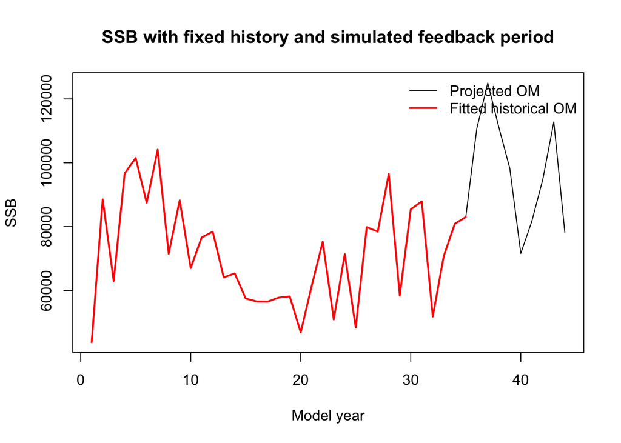

```r
plot(
  om_future$rep$SSB,
  type = "l",
  main = "SSB with fixed history and simulated feedback period",
  xlab = "Model year",
  ylab = "SSB"
)
lines(1:n_hist_years, OM$rep$SSB[1:n_hist_years], col = "red", lwd = 2)

legend(
  "topright",
  legend = c("Projected OM", "Fitted historical OM"),
  col = c("black", "red"),
  lwd = c(1, 2),
  bty = "n"
)
```

NAA comparisons (modified from original age 6, too old for butterfish, set to 3)

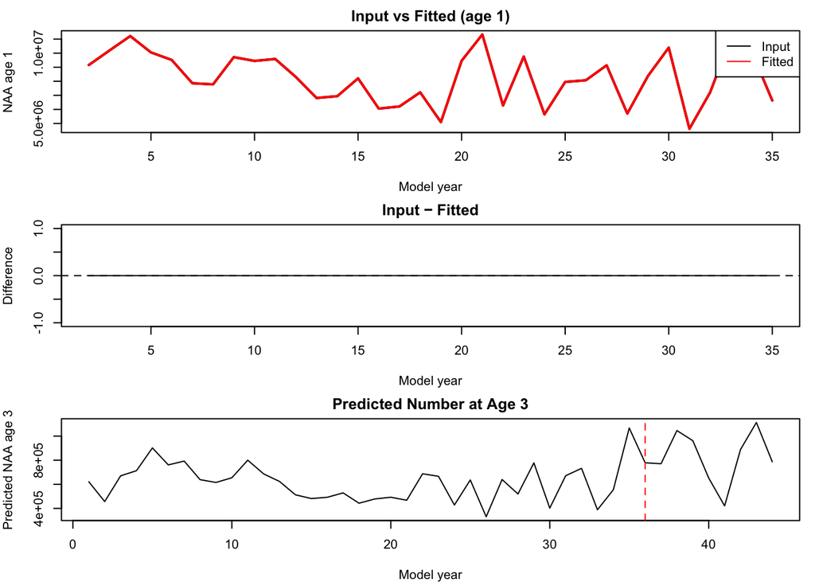

```r
s <- 1
r <- 1
hist_idx <- 1:(n_hist_years - 1L)

layout(matrix(c(1,2,3), nrow = 3, byrow = TRUE))
par(mar = c(4,4,2,1))

# Extract series
input_series <- exp(om_future$input$par$log_NAA[s, r, hist_idx, 1])
fitted_series <- OM$rep$NAA[s, r, hist_idx + 1L, 1]

# Panel 1 — overlay
plot(hist_idx + 1, input_series,
     type = "l",
     lwd = 2,
     xlab = "Model year",
     ylab = "NAA age 1",
     main = "Input vs Fitted (age 1)")
lines(hist_idx + 1, fitted_series, col = "red", lwd = 2)
legend("topright", c("Input", "Fitted"), col=c("black","red"), lty=1)

# Panel 2 — difference
plot(hist_idx + 1,
     input_series - fitted_series,
     type = "l",
     xlab = "Model year",
     ylab = "Difference",
     main = "Input − Fitted")
abline(h = 0, lty = 2)

# Panel 3 — predicted NAA age 3
plot(
  om_future$rep$pred_NAA[s, r, , 3],
  type = "l",
  main = "Predicted Number at Age 3",
  xlab = "Model year",
  ylab = "Predicted NAA age 3"
)
abline(v = first_free_year, lty = 2, col = "red")
```

Rec devs

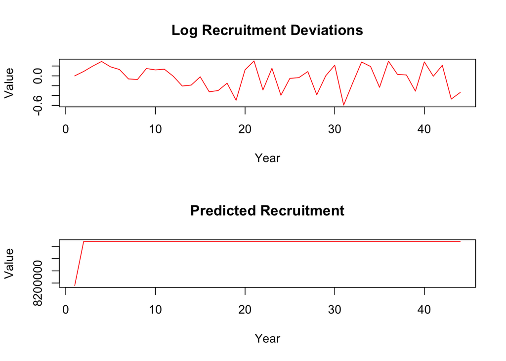

```r
par(mfrow = c(2, 1))

# Recruitment deviations
matplot(
  om_future$rep$NAA_devs[, , , 1],
  type = "l",
  lty = 1,
  col = rainbow(dim(om_future$rep$NAA_devs)[1]),
  main = "Log Recruitment Deviations",
  xlab = "Year",
  ylab = "Value"
)

# Predicted recruitment
matplot(
  om_future$rep$pred_NAA[, , , 1],
  type = "l",
  lty = 1,
  col = rainbow(dim(om_future$rep$pred_NAA)[1]),
  main = "Predicted Recruitment",
  xlab = "Year",
  ylab = "Value"
)
```

```r
par(mfrow = c(1,1))
```

Historical SSB is identical because I did not refit the model, just used 2024 MT as is.

```r
hist_diff <- om_future$rep$NAA[, , 1:n_hist_years, ] -
  OM$rep$NAA[, , 1:n_hist_years, ]
print(hist_diff)
```

```
##       [,1] [,2] [,3] [,4] [,5]
##  [1,]    0    0    0    0    0
##  [2,]    0    0    0    0    0
##  [3,]    0    0    0    0    0
##  [4,]    0    0    0    0    0
##  [5,]    0    0    0    0    0
##  [6,]    0    0    0    0    0
##  [7,]    0    0    0    0    0
##  [8,]    0    0    0    0    0
##  [9,]    0    0    0    0    0
## [10,]    0    0    0    0    0
## [11,]    0    0    0    0    0
## [12,]    0    0    0    0    0
## [13,]    0    0    0    0    0
## [14,]    0    0    0    0    0
```

[output cut: 21 more lines]

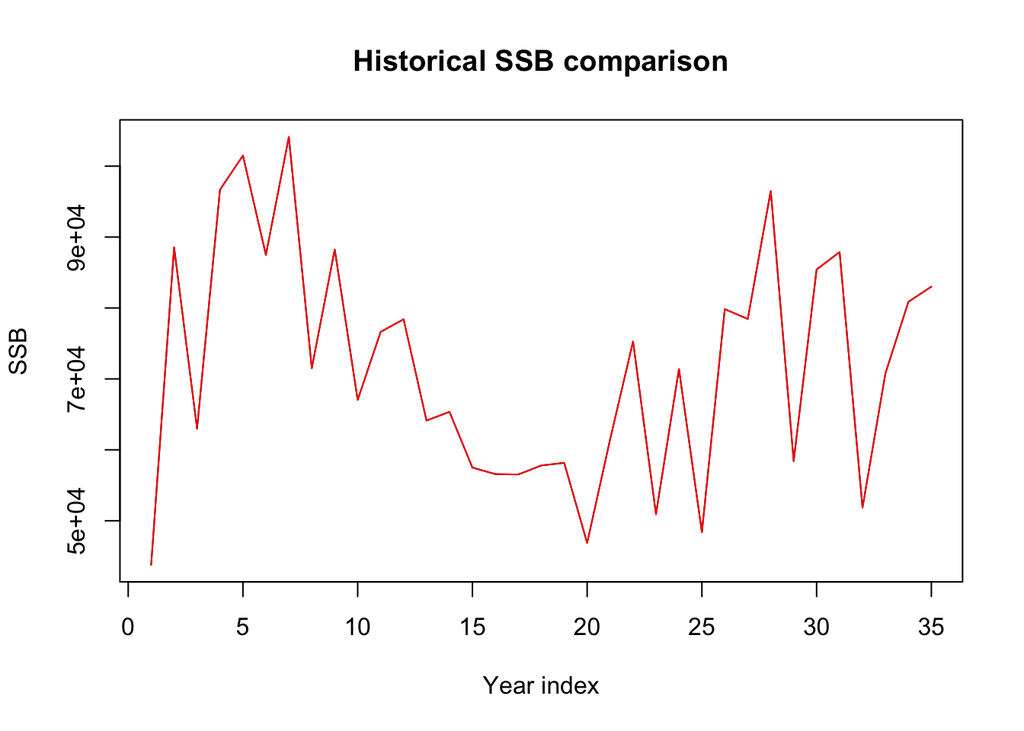

```r
plot(
  om_future$rep$SSB[1:n_hist_years],
  type = "l",
  main = "Historical SSB comparison",
  xlab = "Year index",
  ylab = "SSB"
)
lines(OM$rep$SSB[1:n_hist_years], col = "red")
```

OK but catch history? Predicted catch is the same

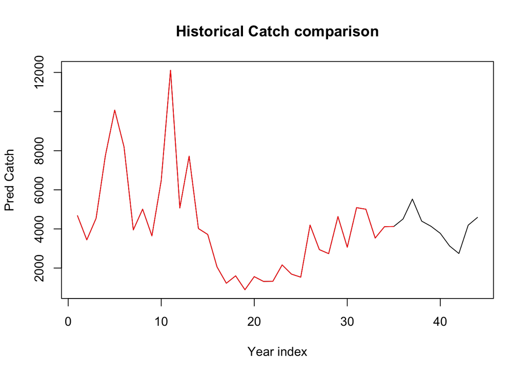

```r
plot(
  om_future$rep$pred_catch, #[1:n_hist_years],
  type = "l",
  main = "Historical Catch comparison",
  xlab = "Year index",
  ylab = "Pred Catch"
)
lines(OM$rep$pred_catch, col = "red")
```

Input catch is different, should I be worried? Input catch appears to go to the EM so maybe yes

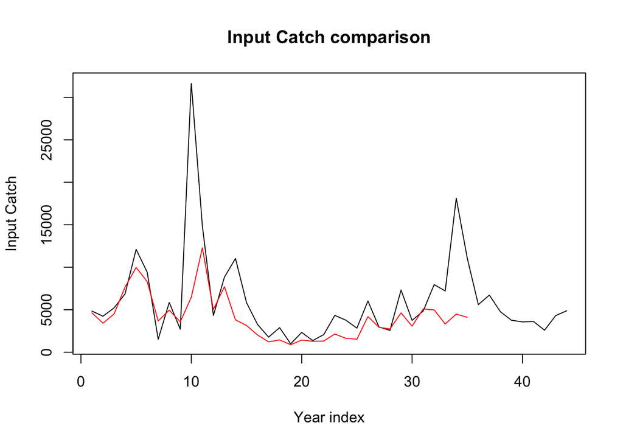

```r
plot(
  om_future$input$data$agg_catch, #[1:n_hist_years],
  type = "l",
  main = "Input Catch comparison",
  xlab = "Year index",
  ylab = "Input Catch"
)
lines(OM$input$data$agg_catch, col = "red")
```

### Now try an MSE

Assessment years and settings for EM, at first change only assessment interval to 3

```r
assess_interval <- 3L
base_years      <- year_start:year_end
terminal_year   <- tail(base_years, 1)

assess_years <- seq(
  terminal_year,
  year_end + MSE_years - assess_interval,
  by = assess_interval
)

NAA_re_em <- NAA_re
NAA_re_em$N1_model <- "equilibrium"
NAA_re_em$sigma    <- "rec" #"rec+1"
NAA_re_em$cor      <- "iid" #"ar1_y"

update_catch_info_list <- list(
  agg_catch_sigma = om_input_P$data$agg_catch_sigma,
  catch_Neff      = om_input_P$data$catch_Neff
)

update_index_info_list <- list(
  agg_index_sigma = om_input_P$data$agg_index_sigma,
  index_Neff      = om_input_P$data$index_Neff,
  remove_agg = TRUE,
  remove_agg_pointer = 1:6,
  remove_agg_years = remove_agg_years1,
  remove_paa = TRUE,
  remove_paa_pointer = 1:6,
  remove_paa_years = remove_paa_years1
)

info$catch_info$selblock_pointer_fleets  <-  om_input_P$data$selblock_pointer_fleets #added
```

HCR Type 1, 75% FXSPR

Some issues:

```r
hcr1 <- list(
  hcr.type = 1,
  hcr.opts = list(use_FXSPR = TRUE, percentFXSPR = 75)
)

# mod1_file <- system.file("extdata", "mod1.RDS", package = "SPASAM.MSE")
#
# if (file.exists(mod1_file)) {
#
#   mod1 <- readRDS(mod1_file)
#
# } else {

  mod1 <- loop_through_fn(
    om = om_future,
    em_info = info,
    random = "log_NAA",
    M_em = M,
    sel_em = sel3,
    NAA_re_em = NAA_re_em,
    age_comp_em = "logistic-normal-pool0",
    em.opt = list(
      separate.em = FALSE,
      separate.em.type = 1,
      do.move = FALSE,
      est.move = FALSE
    ),
    update_index_info = update_index_info_list,
    update_catch_info = update_catch_info_list,
    assess_years = assess_years,
    assess_interval = assess_interval,
    base_years = base_years,
    year.use = 35,
    add.years = TRUE,
    seed = 12345L,
    hcr = hcr1,
    save.sdrep = FALSE,
    save.last.em = TRUE,
    FXSPR_init = 0.5,
    process_fix = TRUE,
    first_free_year = 36
  )
```

```
##
## Now conducting stock assessment for year 2023
```

```
## Using user-specified WAA array. WAA can be time-varying.
```

```
##
##   --------------------
##
##   IMPORTANT!!!!
##
##   For the current version of WHAM, if WAA pointers are specified (i.e., WAA differs across fleets, indices, or stocks),
##
##   they need to be updated *after* prepare_wham_input(). Otherwise, a global WAA will be applied to all components.
##
##   --------------------
##
```

[output not shown]

```
##
## --Creating input---------------------------------------------------------------------------------------------------------------------
```

```
## basic_info done
```

```
## catch done
```

```
## indices done
```

```
## WAA done
```

```
## NAA done
```

```
## q done
```

```
## selectivity done
```

```
## age_comp done
```

```
## F done
```

```
## M done
```

```
## move done
```

```
## osa_obs done
```

```
## --Input Complete--------------------------------------------------------------------------------------------------------------------
```

[output not shown]

[output cut: 25 more lines]

```
## Observations at these ages will be omitted and remaining observations will be rescaled.
##
## Selectivity block 5 has parameters for ages 5+ fixed at 0 and is used by index 4
##  in years 2009, 2010, 2011, 2012, 2013, 2014, 2015, 2016, 2017, 2018, 2019, 2021, 2022.
## Observations at these ages will be omitted and remaining observations will be rescaled.
##
## Selectivity block 6 has parameters for ages 1, 4 fixed at 0 and is used by index 5
##  in years 2008, 2009, 2010, 2011, 2012, 2013, 2014, 2015, 2016, 2018, 2019, 2021, 2022, 2023.
## Observations at these ages will be omitted and remaining observations will be rescaled.
##
## -------------------------------------------------------------------------------------------------------------------------------------
##
## --Reference points-------------------------------------------------------------------------------------------------------------------
## For annual SPR-based reference points, corresponding annual conditionally expected recruitments are used.
## -------------------------------------------------------------------------------------------------------------------------------------
```

```
##
##
##     --------------------
##
##     IMPORTANT!!!
##
##     WAA pointers are updated!
##
##     --------------------
##
```

[output not shown]

```
##
## Now fitting assessment model...
```

```
## Using stats::nlminb for optimization with these control parameters:
```

```
## iter.max: 1000
## eval.max: 1000
```

```
##
## Now checking convergence of assessment model...
```

```
##
## Now generating catch advice...
##
## Harvest Control Rule type 1
## Final Projection Options:
##  n.yrs: 3
##  use.last.F: FALSE
##  use.avg.F: FALSE
##  use.FXSPR: TRUE
##  percentFXSPR: 75
##  use.FMSY: FALSE
##  percentFMSY: 75
##  avg.yrs: 2019, 2020, 2021, 2022, 2023
##  cont.ecov: TRUE
##  use.last.ecov: FALSE
##  cont.M.re: FALSE
##  cont.L.re: FALSE
## Catch Advice
##            Fleet_1
## Year_2024 237729.5
## Year_2025 137158.6
## Year_2026 142169.4
##
## Now calculating F at age in the OM given the catch advice...
##
## Now calculating fleet-specific F in year 2024
```

```
##
## Fishing mortality is 10
##
## Now updating F in OM for year 2024
##
## Now simulating data for year 2024
##
## Now projecting data for years after 2024
##
## Now calculating fleet-specific F in year 2025
##
## Fishing mortality is 10
##
## Now updating F in OM for year 2025
##
## Now simulating data for year 2025
##
## Now projecting data for years after 2025
##
## Now calculating fleet-specific F in year 2026
##
## Fishing mortality is 10
##
## Now updating F in OM for year 2026
##
## Now simulating data for year 2026
##
## Now projecting data for years after 2026
##
## Now conducting stock assessment for year 2026
```

```
## Using user-specified WAA array. WAA can be time-varying.
```

```
##
##   --------------------
##
##   IMPORTANT!!!!
##
##   For the current version of WHAM, if WAA pointers are specified (i.e., WAA differs across fleets, indices, or stocks),
##
##   they need to be updated *after* prepare_wham_input(). Otherwise, a global WAA will be applied to all components.
##
##   --------------------
##
```

[output not shown]

```
##
## --Creating input---------------------------------------------------------------------------------------------------------------------
```

```
## basic_info done
```

```
## catch done
```

```
## indices done
```

```
## WAA done
```

```
## NAA done
```

```
## q done
```

```
## selectivity done
```

```
## age_comp done
```

```
## F done
```

```
## M done
```

```
## move done
```

```
## osa_obs done
```

```
## --Input Complete--------------------------------------------------------------------------------------------------------------------
```

[output not shown]

[output cut: 25 more lines]

```
## Observations at these ages will be omitted and remaining observations will be rescaled.
##
## Selectivity block 5 has parameters for ages 5+ fixed at 0 and is used by index 4
##  in years 2009, 2010, 2011, 2012, 2013, 2014, 2015, 2016, 2017, 2018, 2019, 2021, 2022, 2024, 2025, 2026.
## Observations at these ages will be omitted and remaining observations will be rescaled.
##
## Selectivity block 6 has parameters for ages 1, 4 fixed at 0 and is used by index 5
##  in years 2008, 2009, 2010, 2011, 2012, 2013, 2014, 2015, 2016, 2018, 2019, 2021, 2022, 2023, 2024, 2025, 2026.
## Observations at these ages will be omitted and remaining observations will be rescaled.
##
## -------------------------------------------------------------------------------------------------------------------------------------
##
## --Reference points-------------------------------------------------------------------------------------------------------------------
## For annual SPR-based reference points, corresponding annual conditionally expected recruitments are used.
## -------------------------------------------------------------------------------------------------------------------------------------
```

```
##
##
##     --------------------
##
##     IMPORTANT!!!
##
##     WAA pointers are updated!
##
##     --------------------
##
```

[output not shown]

```
##
## Now fitting assessment model...
```

```
## Using stats::nlminb for optimization with these control parameters:
```

```
## iter.max: 1000
## eval.max: 1000
```

```
##
## Now checking convergence of assessment model...
##
## Assessment model is converged.
##
## Now generating catch advice...
##
## Harvest Control Rule type 1
## Final Projection Options:
##  n.yrs: 3
##  use.last.F: FALSE
##  use.avg.F: FALSE
##  use.FXSPR: TRUE
##  percentFXSPR: 75
##  use.FMSY: FALSE
##  percentFMSY: 75
##  avg.yrs: 2022, 2023, 2024, 2025, 2026
##  cont.ecov: TRUE
##  use.last.ecov: FALSE
##  cont.M.re: FALSE
##  cont.L.re: FALSE
## Catch Advice
##            Fleet_1
## Year_2027 82128.89
## Year_2028 82433.78
## Year_2029 86387.57
##
## Now calculating F at age in the OM given the catch advice...
##
## Now calculating fleet-specific F in year 2027
##
## Fishing mortality is 10
##
## Now updating F in OM for year 2027
##
## Now simulating data for year 2027
##
## Now projecting data for years after 2027
##
## Now calculating fleet-specific F in year 2028
##
## Fishing mortality is 10
##
## Now updating F in OM for year 2028
##
## Now simulating data for year 2028
##
## Now projecting data for years after 2028
##
## Now calculating fleet-specific F in year 2029
##
## Fishing mortality is 10
##
## Now updating F in OM for year 2029
##
## Now simulating data for year 2029
##
## Now projecting data for years after 2029
##
## Now conducting stock assessment for year 2029
```

```
## Using user-specified WAA array. WAA can be time-varying.
```

[output not shown]

[output not shown]

```
##
## --Creating input---------------------------------------------------------------------------------------------------------------------
```

```
## basic_info done
```

```
## catch done
```

```
## indices done
```

```
## WAA done
```

```
## NAA done
```

```
## q done
```

```
## selectivity done
```

```
## age_comp done
```

```
## F done
```

```
## M done
```

```
## move done
```

```
## osa_obs done
```

```
## --Input Complete--------------------------------------------------------------------------------------------------------------------
```

[output not shown]

[output cut: 25 more lines]

```
## Observations at these ages will be omitted and remaining observations will be rescaled.
##
## Selectivity block 5 has parameters for ages 5+ fixed at 0 and is used by index 4
##  in years 2009, 2010, 2011, 2012, 2013, 2014, 2015, 2016, 2017, 2018, 2019, 2021, 2022, 2024, 2025, 2026, 2027, 2028, 2029.
## Observations at these ages will be omitted and remaining observations will be rescaled.
##
## Selectivity block 6 has parameters for ages 1, 4 fixed at 0 and is used by index 5
##  in years 2008, 2009, 2010, 2011, 2012, 2013, 2014, 2015, 2016, 2018, 2019, 2021, 2022, 2023, 2024, 2025, 2026, 2027, 2028, 2029.
## Observations at these ages will be omitted and remaining observations will be rescaled.
##
## -------------------------------------------------------------------------------------------------------------------------------------
##
## --Reference points-------------------------------------------------------------------------------------------------------------------
## For annual SPR-based reference points, corresponding annual conditionally expected recruitments are used.
## -------------------------------------------------------------------------------------------------------------------------------------
```

```
##
##
##     --------------------
##
##     IMPORTANT!!!
##
##     WAA pointers are updated!
##
##     --------------------
##
```

[output not shown]

```
##
## Now fitting assessment model...
```

```
## Using stats::nlminb for optimization with these control parameters:
```

```
## iter.max: 1000
## eval.max: 1000
```

```
##
## Now checking convergence of assessment model...
##
## Assessment model is converged.
##
## Now generating catch advice...
##
## Harvest Control Rule type 1
## Final Projection Options:
##  n.yrs: 3
##  use.last.F: FALSE
##  use.avg.F: FALSE
##  use.FXSPR: TRUE
##  percentFXSPR: 75
##  use.FMSY: FALSE
##  percentFMSY: 75
##  avg.yrs: 2025, 2026, 2027, 2028, 2029
##  cont.ecov: TRUE
##  use.last.ecov: FALSE
##  cont.M.re: FALSE
##  cont.L.re: FALSE
## Catch Advice
##            Fleet_1
## Year_2030 61202.07
## Year_2031 61698.74
## Year_2032 69178.76
##
## Now calculating F at age in the OM given the catch advice...
##
## Now calculating fleet-specific F in year 2030
##
## Fishing mortality is 6.91522720561367
##
## Now updating F in OM for year 2030
##
## Now simulating data for year 2030
##
## Now projecting data for years after 2030
##
## Now calculating fleet-specific F in year 2031
##
## Fishing mortality is 5.01634945004397
##
## Now updating F in OM for year 2031
##
## Now simulating data for year 2031
##
## Now projecting data for years after 2031
##
## Now calculating fleet-specific F in year 2032
##
## Fishing mortality is 10
##
## Now updating F in OM for year 2032
##
## Now simulating data for year 2032
##
## Now projecting data for years after 2032
## Please ignore Warning in check_projF(proj_mod).
## Total Runtime =  17.78324
```

```r
#}
```

Compare

Catch: real assessment input (red) predicted (blue), om_future input(black), om_future predicted (orange), and EM [[3]] input (black dashed) and predicted (green dashed)

Confirming that implemented EM catch is *way* too high, doesn’t seem the EM can recover from this

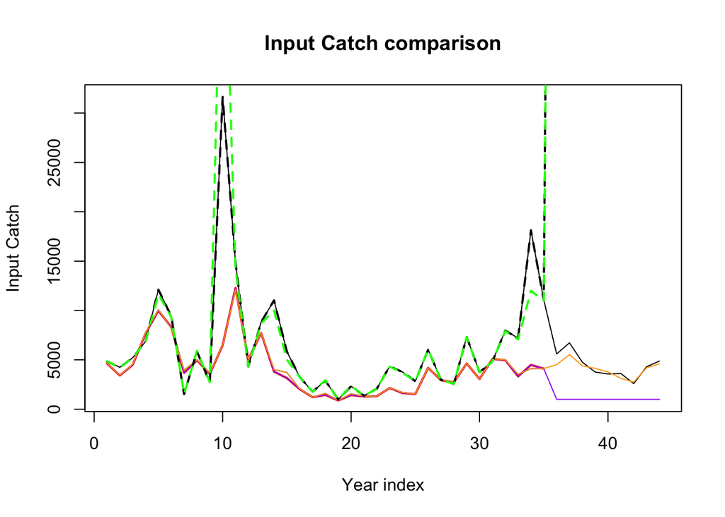

```r
plot(
  om_future$input$data$agg_catch, #[1:n_hist_years],
  type = "l",
  main = "Input Catch comparison",
  xlab = "Year index",
  ylab = "Input Catch"
)
lines(OM$input$data$agg_catch, col = "red", lwd = 2)
lines(OM$rep$pred_catch, col = "blue")
#lines(unfitted_om_P$rep$pred_catch, col = "blue")
lines(unfitted_om_P$input$data$agg_catch, col = "purple")
lines(om_future$rep$pred_catch, col = "orange")
lines(mod1$em_input[[3]]$data$agg_catch, lwd = 2, lty = 2)
lines(mod1$em_list[[3]]$pred_catch, col = "green", lwd = 2, lty = 2)
```

```r
#lines(mod1$em_input[[2]]$data$agg_catch, lwd = 2, lty = 2)
```

Indices

Albatross: real assessment input (red), om_future input(black), om_future predicted (orange), and EM [[3]] input (black dashed) and predicted (green dashed)

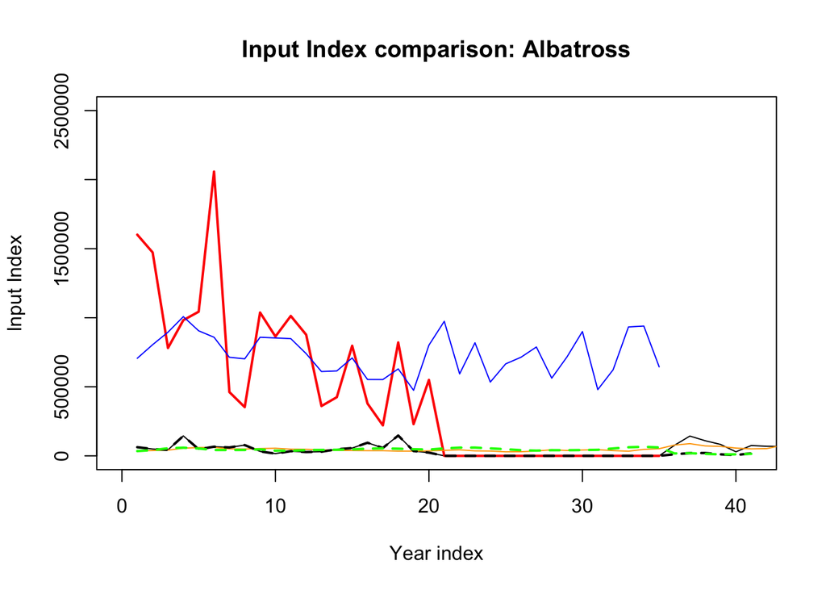

```r
plot(
  om_future$input$data$agg_indices[,1],
  type = "l",
  main = "Input Index comparison: Albatross",
  xlab = "Year index",
  ylab = "Input Index",
  ylim = c(0, 2500000),
  xlim = c(0, 41)
)
lines(OM$input$data$agg_indices[,1], col = "red", lwd = 2)
lines(OM$rep$pred_indices[,1], col = "blue")
#lines(unfitted_om_P$rep$pred_catch, col = "blue")
#lines(unfitted_om_P$input$data$agg_catch, col = "purple")
lines(om_future$rep$pred_indices[,1], col = "orange")
lines(mod1$em_input[[3]]$data$agg_indices[,1], lwd = 2, lty = 2)
lines(mod1$em_list[[3]]$pred_indices[,1], col = "green", lwd = 2, lty = 2)
```

```r
#lines(mod1$em_input[[2]]$data$agg_catch, lwd = 2, lty = 2)
```

Fall Bigelow: real assessment input (red), om_future input(black), om_future predicted (orange), and EM [[3]] input (black dashed) and predicted (green dashed)

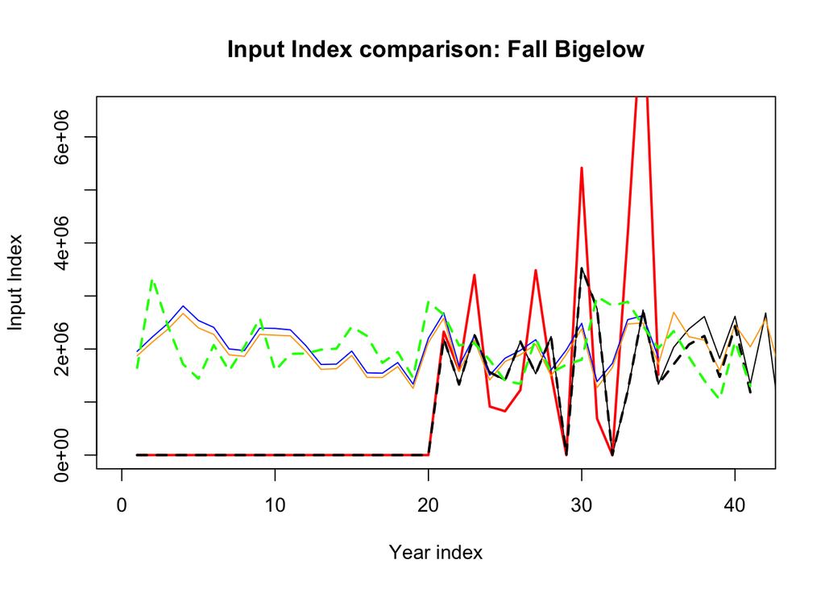

```r
plot(
  om_future$input$data$agg_indices[,2],
  type = "l",
  main = "Input Index comparison: Fall Bigelow",
  xlab = "Year index",
  ylab = "Input Index",
  ylim = c(0, 6500000),
  xlim = c(0, 41)
)
lines(OM$input$data$agg_indices[,2], col = "red", lwd = 2)
lines(OM$rep$pred_indices[,2], col = "blue")
#lines(unfitted_om_P$rep$pred_catch, col = "blue")
#lines(unfitted_om_P$input$data$agg_catch, col = "purple")
lines(om_future$rep$pred_indices[,2], col = "orange")
lines(mod1$em_input[[3]]$data$agg_indices[,2], lwd = 2, lty = 2)
lines(mod1$em_list[[3]]$pred_indices[,2], col = "green", lwd = 2, lty = 2)
```

```r
#lines(mod1$em_input[[2]]$data$agg_catch, lwd = 2, lty = 2)
```

Fall NEAMAP: real assessment input (red), om_future input(black), om_future predicted (orange), and EM [[3]] input (black dashed) and predicted (green dashed)

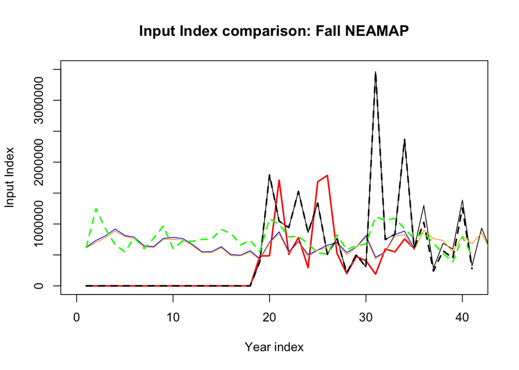

```r
plot(
  om_future$input$data$agg_indices[,3],
  type = "l",
  main = "Input Index comparison: Fall NEAMAP",
  xlab = "Year index",
  ylab = "Input Index",
  ylim = c(0, 3500000),
  xlim = c(0, 41)
)
lines(OM$input$data$agg_indices[,3], col = "red", lwd = 2)
lines(OM$rep$pred_indices[,3], col = "blue")
#lines(unfitted_om_P$rep$pred_catch, col = "blue")
#lines(unfitted_om_P$input$data$agg_catch, col = "purple")
lines(om_future$rep$pred_indices[,3], col = "orange")
lines(mod1$em_input[[3]]$data$agg_indices[,3], lwd = 2, lty = 2)
lines(mod1$em_list[[3]]$pred_indices[,3], col = "green", lwd = 2, lty = 2)
```

```r
#lines(mod1$em_input[[2]]$data$agg_catch, lwd = 2, lty = 2)
```

Spring Bigelow: real assessment input (red), om_future input(black), om_future predicted (orange), and EM [[3]] input (black dashed) and predicted (green dashed)

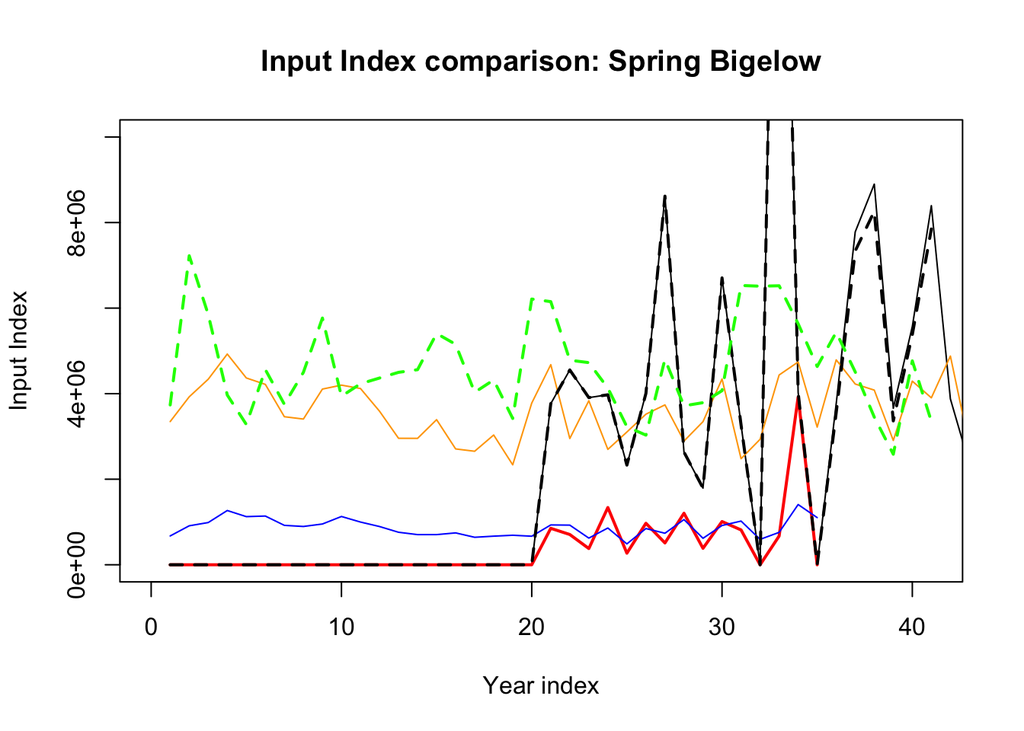

```r
plot(
  om_future$input$data$agg_indices[,4],
  type = "l",
  main = "Input Index comparison: Spring Bigelow",
  xlab = "Year index",
  ylab = "Input Index",
  ylim = c(0, 10000000),
  xlim = c(0, 41)
)
lines(OM$input$data$agg_indices[,4], col = "red", lwd = 2)
lines(OM$rep$pred_indices[,4], col = "blue")
#lines(unfitted_om_P$rep$pred_catch, col = "blue")
#lines(unfitted_om_P$input$data$agg_catch, col = "purple")
lines(om_future$rep$pred_indices[,4], col = "orange")
lines(mod1$em_input[[3]]$data$agg_indices[,4], lwd = 2, lty = 2)
lines(mod1$em_list[[3]]$pred_indices[,4], col = "green", lwd = 2, lty = 2)
```

```r
#lines(mod1$em_input[[2]]$data$agg_catch, lwd = 2, lty = 2)
```

Spring NEAMAP: real assessment input (red), om_future input(black), om_future predicted (orange), and EM [[3]] input (black dashed) and predicted (green dashed)

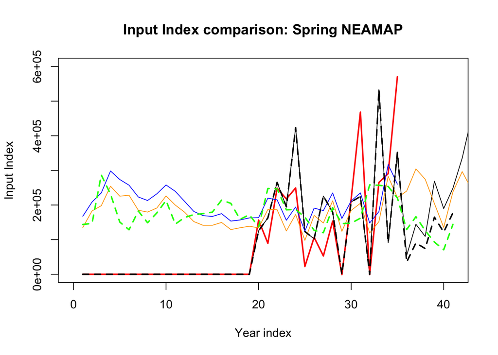

```r
plot(
  om_future$input$data$agg_indices[,5],
  type = "l",
  main = "Input Index comparison: Spring NEAMAP",
  xlab = "Year index",
  ylab = "Input Index",
  ylim = c(0, 600000),
  xlim = c(0, 41)
)
lines(OM$input$data$agg_indices[,5], col = "red", lwd = 2)
lines(OM$rep$pred_indices[,5], col = "blue")
#lines(unfitted_om_P$rep$pred_catch, col = "blue")
#lines(unfitted_om_P$input$data$agg_catch, col = "purple")
lines(om_future$rep$pred_indices[,5], col = "orange")
lines(mod1$em_input[[3]]$data$agg_indices[,5], lwd = 2, lty = 2)
lines(mod1$em_list[[3]]$pred_indices[,5], col = "green", lwd = 2, lty = 2)
```

```r
#lines(mod1$em_input[[2]]$data$agg_catch, lwd = 2, lty = 2)
```

YOY: real assessment input (red), om_future input(black), om_future predicted (orange), and EM [[3]] input (black dashed) and predicted (green dashed)

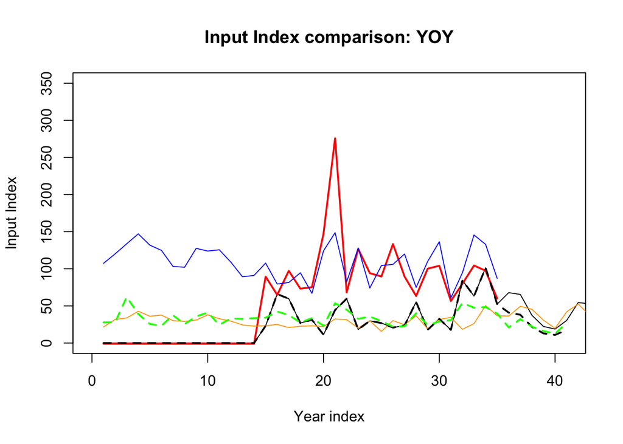

```r
plot(
  om_future$input$data$agg_indices[,6],
  type = "l",
  main = "Input Index comparison: YOY",
  xlab = "Year index",
  ylab = "Input Index",
  ylim = c(0, 350),
  xlim = c(0, 41)
)
lines(OM$input$data$agg_indices[,6], col = "red", lwd = 2)
lines(OM$rep$pred_indices[,6], col = "blue")
#lines(unfitted_om_P$rep$pred_catch, col = "blue")
#lines(unfitted_om_P$input$data$agg_catch, col = "purple")
lines(om_future$rep$pred_indices[,6], col = "orange")
lines(mod1$em_input[[3]]$data$agg_indices[,6], lwd = 2, lty = 2)
lines(mod1$em_list[[3]]$pred_indices[,6], col = "green", lwd = 2, lty = 2)
```

```r
#lines(mod1$em_input[[2]]$data$agg_catch, lwd = 2, lty = 2)
```

Age comps are also reportedly 0s

HCR Type 1, Set F to 2/3 M

```r
hcr2 <- list(
  hcr.type = 1,
  hcr.opts = list(use_FXSPR = TRUE, percentFXSPR = 16) # try to get closer to 2/3 M ref pt
)

# mod2_file <- system.file("extdata", "mod2.RDS", package = "SPASAM.MSE")
#
# if (file.exists(mod2_file)) {
#
#   mod2 <- readRDS(mod2_file)
#
# } else {

  mod2 <- loop_through_fn(
    om = om_future,
    em_info = info,
    random = "log_NAA",
    M_em = M,
    sel_em = sel3,
    NAA_re_em = NAA_re_em,
    age_comp_em = "logistic-normal-pool0",
    em.opt = list(
      separate.em = FALSE,
      separate.em.type = 1,
      do.move = FALSE,
      est.move = FALSE
    ),
    update_index_info = update_index_info_list,
    update_catch_info = update_catch_info_list,
    assess_years = assess_years,
    assess_interval = assess_interval,
    base_years = base_years,
    year.use = 35,
    add.years = TRUE,
    seed = 12345L,
    hcr = hcr2,
    save.sdrep = FALSE,
    save.last.em = TRUE,
    FXSPR_init = 0.5,
    process_fix = TRUE,
    first_free_year = 36
  )
```

```
##
## Now conducting stock assessment for year 2023
```

```
## Using user-specified WAA array. WAA can be time-varying.
```

[output not shown]

[output not shown]

```
##
## --Creating input---------------------------------------------------------------------------------------------------------------------
```

```
## basic_info done
```

```
## catch done
```

```
## indices done
```

```
## WAA done
```

```
## NAA done
```

```
## q done
```

```
## selectivity done
```

```
## age_comp done
```

```
## F done
```

```
## M done
```

```
## move done
```

```
## osa_obs done
```

```
## --Input Complete--------------------------------------------------------------------------------------------------------------------
```

[output not shown]

[output cut: 25 more lines]

[output not shown]

```
##
##
##     --------------------
##
##     IMPORTANT!!!
##
##     WAA pointers are updated!
##
##     --------------------
##
```

[output not shown]

```
##
## Now fitting assessment model...
```

```
## Using stats::nlminb for optimization with these control parameters:
```

```
## iter.max: 1000
## eval.max: 1000
```

```
##
## Now checking convergence of assessment model...
```

```
##
## Now generating catch advice...
##
## Harvest Control Rule type 1
## Final Projection Options:
##  n.yrs: 3
##  use.last.F: FALSE
##  use.avg.F: FALSE
##  use.FXSPR: TRUE
##  percentFXSPR: 16
##  use.FMSY: FALSE
##  percentFMSY: 75
##  avg.yrs: 2019, 2020, 2021, 2022, 2023
##  cont.ecov: TRUE
##  use.last.ecov: FALSE
##  cont.M.re: FALSE
##  cont.L.re: FALSE
## Catch Advice
##            Fleet_1
## Year_2024 76020.75
## Year_2025 56794.93
## Year_2026 56514.73
##
## Now calculating F at age in the OM given the catch advice...
##
## Now calculating fleet-specific F in year 2024
##
## Fishing mortality is 2.54950575144324
##
## Now updating F in OM for year 2024
##
## Now simulating data for year 2024
##
## Now projecting data for years after 2024
##
## Now calculating fleet-specific F in year 2025
##
## Fishing mortality is 2.74893115732728
##
## Now updating F in OM for year 2025
##
## Now simulating data for year 2025
##
## Now projecting data for years after 2025
##
## Now calculating fleet-specific F in year 2026
##
## Fishing mortality is 3.77757896251031
##
## Now updating F in OM for year 2026
##
## Now simulating data for year 2026
##
## Now projecting data for years after 2026
##
## Now conducting stock assessment for year 2026
```

```
## Using user-specified WAA array. WAA can be time-varying.
```

[output not shown]

[output not shown]

```
##
## --Creating input---------------------------------------------------------------------------------------------------------------------
```

```
## basic_info done
```

```
## catch done
```

```
## indices done
```

```
## WAA done
```

```
## NAA done
```

```
## q done
```

```
## selectivity done
```

```
## age_comp done
```

```
## F done
```

```
## M done
```

```
## move done
```

```
## osa_obs done
```

```
## --Input Complete--------------------------------------------------------------------------------------------------------------------
```

[output not shown]

[output cut: 25 more lines]

[output not shown]

```
##
##
##     --------------------
##
##     IMPORTANT!!!
##
##     WAA pointers are updated!
##
##     --------------------
##
```

[output not shown]

```
##
## Now fitting assessment model...
```

```
## Using stats::nlminb for optimization with these control parameters:
```

```
## iter.max: 1000
## eval.max: 1000
```

```
##
## Now checking convergence of assessment model...
##
## Assessment model is converged.
##
## Now generating catch advice...
##
## Harvest Control Rule type 1
## Final Projection Options:
##  n.yrs: 3
##  use.last.F: FALSE
##  use.avg.F: FALSE
##  use.FXSPR: TRUE
##  percentFXSPR: 16
##  use.FMSY: FALSE
##  percentFMSY: 75
##  avg.yrs: 2022, 2023, 2024, 2025, 2026
##  cont.ecov: TRUE
##  use.last.ecov: FALSE
##  cont.M.re: FALSE
##  cont.L.re: FALSE
## Catch Advice
##            Fleet_1
## Year_2027 31366.29
## Year_2028 32636.73
## Year_2029 34859.67
##
## Now calculating F at age in the OM given the catch advice...
##
## Now calculating fleet-specific F in year 2027
##
## Fishing mortality is 1.98955637584122
##
## Now updating F in OM for year 2027
##
## Now simulating data for year 2027
##
## Now projecting data for years after 2027
##
## Now calculating fleet-specific F in year 2028
##
## Fishing mortality is 2.38494245493805
##
## Now updating F in OM for year 2028
##
## Now simulating data for year 2028
##
## Now projecting data for years after 2028
##
## Now calculating fleet-specific F in year 2029
##
## Fishing mortality is 3.00562957046226
##
## Now updating F in OM for year 2029
##
## Now simulating data for year 2029
##
## Now projecting data for years after 2029
##
## Now conducting stock assessment for year 2029
```

```
## Using user-specified WAA array. WAA can be time-varying.
```

[output not shown]

[output not shown]

```
##
## --Creating input---------------------------------------------------------------------------------------------------------------------
```

```
## basic_info done
```

```
## catch done
```

```
## indices done
```

```
## WAA done
```

```
## NAA done
```

```
## q done
```

```
## selectivity done
```

```
## age_comp done
```

```
## F done
```

```
## M done
```

```
## move done
```

```
## osa_obs done
```

```
## --Input Complete--------------------------------------------------------------------------------------------------------------------
```

[output not shown]

[output cut: 25 more lines]

[output not shown]

```
##
##
##     --------------------
##
##     IMPORTANT!!!
##
##     WAA pointers are updated!
##
##     --------------------
##
```

[output not shown]

```
##
## Now fitting assessment model...
```

```
## Using stats::nlminb for optimization with these control parameters:
```

```
## iter.max: 1000
## eval.max: 1000
```

```
##
## Now checking convergence of assessment model...
##
## Assessment model is converged.
##
## Now generating catch advice...
##
## Harvest Control Rule type 1
## Final Projection Options:
##  n.yrs: 3
##  use.last.F: FALSE
##  use.avg.F: FALSE
##  use.FXSPR: TRUE
##  percentFXSPR: 16
##  use.FMSY: FALSE
##  percentFMSY: 75
##  avg.yrs: 2025, 2026, 2027, 2028, 2029
##  cont.ecov: TRUE
##  use.last.ecov: FALSE
##  cont.M.re: FALSE
##  cont.L.re: FALSE
## Catch Advice
##            Fleet_1
## Year_2030 31308.12
## Year_2031 29259.46
## Year_2032 31613.98
##
## Now calculating F at age in the OM given the catch advice...
##
## Now calculating fleet-specific F in year 2030
##
## Fishing mortality is 2.22570233053938
##
## Now updating F in OM for year 2030
##
## Now simulating data for year 2030
##
## Now projecting data for years after 2030
##
## Now calculating fleet-specific F in year 2031
##
## Fishing mortality is 1.14291051397001
##
## Now updating F in OM for year 2031
##
## Now simulating data for year 2031
##
## Now projecting data for years after 2031
##
## Now calculating fleet-specific F in year 2032
##
## Fishing mortality is 1.48021296848901
##
## Now updating F in OM for year 2032
##
## Now simulating data for year 2032
##
## Now projecting data for years after 2032
## Please ignore Warning in check_projF(proj_mod).
## Total Runtime =  17.9813
```

```r
#}
```

Now try the MAFMC rule, HCR type 4

But I would need to sub in the SSC F OFL so the function needs modification, this still uses 100% F_XSPR as F_OFL

Also, does the SSC just sub in the F and not recalculate SSB_FXSPR? If so I can modify the function, if not it is WAY more complex.

This is full FXSPR

```r
hcr3 <- list(
  hcr.type = 4,
  hcr.opts = list(use_FXSPR = TRUE)
)

# mod2_file <- system.file("extdata", "mod2.RDS", package = "SPASAM.MSE")
#
# if (file.exists(mod2_file)) {
#
#   mod2 <- readRDS(mod2_file)
#
# } else {

  mod3 <- loop_through_fn(
    om = om_future,
    em_info = info,
    random = "log_NAA",
    M_em = M,
    sel_em = sel3,
    NAA_re_em = NAA_re_em,
    age_comp_em = "logistic-normal-pool0",
    em.opt = list(
      separate.em = FALSE,
      separate.em.type = 1,
      do.move = FALSE,
      est.move = FALSE
    ),
    update_index_info = update_index_info_list,
    update_catch_info = update_catch_info_list,
    assess_years = assess_years,
    assess_interval = assess_interval,
    base_years = base_years,
    year.use = 35,
    add.years = TRUE,
    seed = 12345L,
    hcr = hcr3,
    save.sdrep = FALSE,
    save.last.em = TRUE,
    FXSPR_init = 0.5,
    process_fix = TRUE,
    first_free_year = 36
  )
```

```
##
## Now conducting stock assessment for year 2023
```

```
## Using user-specified WAA array. WAA can be time-varying.
```

[output not shown]

[output not shown]

```
##
## --Creating input---------------------------------------------------------------------------------------------------------------------
```

```
## basic_info done
```

```
## catch done
```

```
## indices done
```

```
## WAA done
```

```
## NAA done
```

```
## q done
```

```
## selectivity done
```

```
## age_comp done
```

```
## F done
```

```
## M done
```

```
## move done
```

```
## osa_obs done
```

```
## --Input Complete--------------------------------------------------------------------------------------------------------------------
```

[output not shown]

[output cut: 25 more lines]

[output not shown]

```
##
##
##     --------------------
##
##     IMPORTANT!!!
##
##     WAA pointers are updated!
##
##     --------------------
##
```

[output not shown]

```
##
## Now fitting assessment model...
```

```
## Using stats::nlminb for optimization with these control parameters:
```

```
## iter.max: 1000
## eval.max: 1000
```

```
##
## Now checking convergence of assessment model...
```

```
##
## Now generating catch advice...
##
## Harvest Control Rule type 4
## SSB_t / SSB_XSPR = 2.998 -> pstar = 0.49; OFL = 278653.943
## SSB_t / SSB_XSPR = 1.034 -> pstar = 0.45; OFL = 162502.829
## SSB_t / SSB_XSPR = 1.042 -> pstar = 0.45; OFL = 165161.806
## Final Projection Options:
##  n.yrs: 3
##  use.last.F: FALSE
##  use.avg.F: FALSE
##  use.FXSPR: FALSE
##  use.FMSY: FALSE
##  avg.yrs: 2019, 2020, 2021, 2022, 2023
##  cont.ecov: TRUE
##  use.last.ecov: FALSE
##  cont.M.re: FALSE
##  cont.L.re: FALSE
##  proj.catch: 273853.754337805, 149661.508449384, 152285.386310211
## Catch Advice
##            Fleet_1
## Year_2024 273853.8
## Year_2025 149661.5
## Year_2026 152285.4
##
## Now calculating F at age in the OM given the catch advice...
##
## Now calculating fleet-specific F in year 2024
##
## Fishing mortality is 10
##
## Now updating F in OM for year 2024
##
## Now simulating data for year 2024
##
## Now projecting data for years after 2024
##
## Now calculating fleet-specific F in year 2025
##
## Fishing mortality is 10
##
## Now updating F in OM for year 2025
##
## Now simulating data for year 2025
##
## Now projecting data for years after 2025
##
## Now calculating fleet-specific F in year 2026
##
## Fishing mortality is 10
##
## Now updating F in OM for year 2026
##
## Now simulating data for year 2026
##
## Now projecting data for years after 2026
##
## Now conducting stock assessment for year 2026
```

```
## Using user-specified WAA array. WAA can be time-varying.
```

[output not shown]

[output not shown]

```
##
## --Creating input---------------------------------------------------------------------------------------------------------------------
```

```
## basic_info done
```

```
## catch done
```

```
## indices done
```

```
## WAA done
```

```
## NAA done
```

```
## q done
```

```
## selectivity done
```

```
## age_comp done
```

```
## F done
```

```
## M done
```

```
## move done
```

```
## osa_obs done
```

```
## --Input Complete--------------------------------------------------------------------------------------------------------------------
```

[output not shown]

[output cut: 25 more lines]

[output not shown]

```
##
##
##     --------------------
##
##     IMPORTANT!!!
##
##     WAA pointers are updated!
##
##     --------------------
##
```

[output not shown]

```
##
## Now fitting assessment model...
```

```
## Using stats::nlminb for optimization with these control parameters:
```

```
## iter.max: 1000
## eval.max: 1000
```

```
##
## Now checking convergence of assessment model...
##
## Assessment model is converged.
##
## Now generating catch advice...
##
## Harvest Control Rule type 4
## SSB_t / SSB_XSPR = 1.147 -> pstar = 0.46; OFL = 100852.569
## SSB_t / SSB_XSPR = 0.969 -> pstar = 0.43; OFL = 99783.762
## SSB_t / SSB_XSPR = 0.983 -> pstar = 0.44; OFL = 102599.439
## Final Projection Options:
##  n.yrs: 3
##  use.last.F: FALSE
##  use.avg.F: FALSE
##  use.FXSPR: FALSE
##  use.FMSY: FALSE
##  avg.yrs: 2022, 2023, 2024, 2025, 2026
##  cont.ecov: TRUE
##  use.last.ecov: FALSE
##  cont.M.re: FALSE
##  cont.L.re: FALSE
##  proj.catch: 94356.0317143742, 88981.9772710212, 92676.8326249507
## Catch Advice
##            Fleet_1
## Year_2027 94356.03
## Year_2028 88981.98
## Year_2029 92676.83
##
## Now calculating F at age in the OM given the catch advice...
##
## Now calculating fleet-specific F in year 2027
##
## Fishing mortality is 10
##
## Now updating F in OM for year 2027
##
## Now simulating data for year 2027
##
## Now projecting data for years after 2027
##
## Now calculating fleet-specific F in year 2028
##
## Fishing mortality is 10
##
## Now updating F in OM for year 2028
##
## Now simulating data for year 2028
##
## Now projecting data for years after 2028
##
## Now calculating fleet-specific F in year 2029
##
## Fishing mortality is 10
##
## Now updating F in OM for year 2029
##
## Now simulating data for year 2029
##
## Now projecting data for years after 2029
##
## Now conducting stock assessment for year 2029
```

```
## Using user-specified WAA array. WAA can be time-varying.
```

[output not shown]

[output not shown]

```
##
## --Creating input---------------------------------------------------------------------------------------------------------------------
```

```
## basic_info done
```

```
## catch done
```

```
## indices done
```

```
## WAA done
```

```
## NAA done
```

```
## q done
```

```
## selectivity done
```

```
## age_comp done
```

```
## F done
```

```
## M done
```

```
## move done
```

```
## osa_obs done
```

```
## --Input Complete--------------------------------------------------------------------------------------------------------------------
```

[output not shown]

[output cut: 25 more lines]

[output not shown]

```
##
##
##     --------------------
##
##     IMPORTANT!!!
##
##     WAA pointers are updated!
##
##     --------------------
##
```

[output not shown]

```
##
## Now fitting assessment model...
```

```
## Using stats::nlminb for optimization with these control parameters:
```

```
## iter.max: 1000
## eval.max: 1000
```

```
##
## Now checking convergence of assessment model...
##
## Assessment model is converged.
##
## Now generating catch advice...
##
## Harvest Control Rule type 4
## SSB_t / SSB_XSPR = 1.098 -> pstar = 0.46; OFL = 75041.637
## SSB_t / SSB_XSPR = 0.962 -> pstar = 0.43; OFL = 80363.979
## SSB_t / SSB_XSPR = 0.967 -> pstar = 0.43; OFL = 81272.171
## Final Projection Options:
##  n.yrs: 3
##  use.last.F: FALSE
##  use.avg.F: FALSE
##  use.FXSPR: FALSE
##  use.FMSY: FALSE
##  avg.yrs: 2025, 2026, 2027, 2028, 2029
##  cont.ecov: TRUE
##  use.last.ecov: FALSE
##  cont.M.re: FALSE
##  cont.L.re: FALSE
##  proj.catch: 69731.7321516674, 71224.5924624665, 72396.8257856426
## Catch Advice
##            Fleet_1
## Year_2030 69731.73
## Year_2031 71224.59
## Year_2032 72396.83
##
## Now calculating F at age in the OM given the catch advice...
##
## Now calculating fleet-specific F in year 2030
##
## Fishing mortality is 8.23949793135731
##
## Now updating F in OM for year 2030
##
## Now simulating data for year 2030
##
## Now projecting data for years after 2030
##
## Now calculating fleet-specific F in year 2031
##
## Fishing mortality is 6.85632828481907
##
## Now updating F in OM for year 2031
##
## Now simulating data for year 2031
##
## Now projecting data for years after 2031
##
## Now calculating fleet-specific F in year 2032
##
## Fishing mortality is 10
##
## Now updating F in OM for year 2032
##
## Now simulating data for year 2032
##
## Now projecting data for years after 2032
## Please ignore Warning in check_projF(proj_mod).
## Total Runtime =  25.74576
```

This tries to cut back the F OFL as the SSC does but without changing SSB_MSY

My hack only works for the first OFL

```r
hcr4 <- list(
  hcr.type = 4,
  hcr.opts = list(use_FXSPR = TRUE, percentFXSPR = 16) # try to get closer to 2/3 M ref pt
)

# mod2_file <- system.file("extdata", "mod2.RDS", package = "SPASAM.MSE")
#
# if (file.exists(mod2_file)) {
#
#   mod2 <- readRDS(mod2_file)
#
# } else {

  mod4 <- loop_through_fn(
    om = om_future,
    em_info = info,
    random = "log_NAA",
    M_em = M,
    sel_em = sel3,
    NAA_re_em = NAA_re_em,
    age_comp_em = "logistic-normal-pool0",
    em.opt = list(
      separate.em = FALSE,
      separate.em.type = 1,
      do.move = FALSE,
      est.move = FALSE
    ),
    update_index_info = update_index_info_list,
    update_catch_info = update_catch_info_list,
    assess_years = assess_years,
    assess_interval = assess_interval,
    base_years = base_years,
    year.use = 35,
    add.years = TRUE,
    seed = 12345L,
    hcr = hcr4,
    save.sdrep = FALSE,
    save.last.em = TRUE,
    FXSPR_init = 0.5,
    process_fix = TRUE,
    first_free_year = 36
  )
```

```
##
## Now conducting stock assessment for year 2023
```

```
## Using user-specified WAA array. WAA can be time-varying.
```

[output not shown]

[output not shown]

```
##
## --Creating input---------------------------------------------------------------------------------------------------------------------
```

```
## basic_info done
```

```
## catch done
```

```
## indices done
```

```
## WAA done
```

```
## NAA done
```

```
## q done
```

```
## selectivity done
```

```
## age_comp done
```

```
## F done
```

```
## M done
```

```
## move done
```

```
## osa_obs done
```

```
## --Input Complete--------------------------------------------------------------------------------------------------------------------
```

[output not shown]

[output cut: 25 more lines]

[output not shown]

```
##
##
##     --------------------
##
##     IMPORTANT!!!
##
##     WAA pointers are updated!
##
##     --------------------
##
```

[output not shown]

```
##
## Now fitting assessment model...
```

```
## Using stats::nlminb for optimization with these control parameters:
```

```
## iter.max: 1000
## eval.max: 1000
```

```
##
## Now checking convergence of assessment model...
```

```
##
## Now generating catch advice...
##
## Harvest Control Rule type 4
## SSB_t / SSB_XSPR = 2.998 -> pstar = 0.49; OFL = 76020.747
## SSB_t / SSB_XSPR = 1.040 -> pstar = 0.45; OFL = 165611.681
## SSB_t / SSB_XSPR = 1.108 -> pstar = 0.46; OFL = 190455.474
## Final Projection Options:
##  n.yrs: 3
##  use.last.F: FALSE
##  use.avg.F: FALSE
##  use.FXSPR: FALSE
##  use.FMSY: FALSE
##  avg.yrs: 2019, 2020, 2021, 2022, 2023
##  cont.ecov: TRUE
##  use.last.ecov: FALSE
##  cont.M.re: FALSE
##  cont.L.re: FALSE
##  proj.catch: 74711.1877716643, 152659.704782662, 177231.789952091
## Catch Advice
##             Fleet_1
## Year_2024  74711.19
## Year_2025 152659.70
## Year_2026 177231.79
##
## Now calculating F at age in the OM given the catch advice...
##
## Now calculating fleet-specific F in year 2024
##
## Fishing mortality is 2.48363073586416
##
## Now updating F in OM for year 2024
##
## Now simulating data for year 2024
##
## Now projecting data for years after 2024
##
## Now calculating fleet-specific F in year 2025
##
## Fishing mortality is 10
##
## Now updating F in OM for year 2025
##
## Now simulating data for year 2025
##
## Now projecting data for years after 2025
##
## Now calculating fleet-specific F in year 2026
##
## Fishing mortality is 10
##
## Now updating F in OM for year 2026
##
## Now simulating data for year 2026
##
## Now projecting data for years after 2026
##
## Now conducting stock assessment for year 2026
```

```
## Using user-specified WAA array. WAA can be time-varying.
```

[output not shown]

[output not shown]

```
##
## --Creating input---------------------------------------------------------------------------------------------------------------------
```

```
## basic_info done
```

```
## catch done
```

```
## indices done
```

```
## WAA done
```

```
## NAA done
```

```
## q done
```

```
## selectivity done
```

```
## age_comp done
```

```
## F done
```

```
## M done
```

```
## move done
```

```
## osa_obs done
```

```
## --Input Complete--------------------------------------------------------------------------------------------------------------------
```

[output not shown]

[output cut: 25 more lines]

[output not shown]

```
##
##
##     --------------------
##
##     IMPORTANT!!!
##
##     WAA pointers are updated!
##
##     --------------------
##
```

[output not shown]

```
##
## Now fitting assessment model...
```

```
## Using stats::nlminb for optimization with these control parameters:
```

```
## iter.max: 1000
## eval.max: 1000
```

```
##
## Now checking convergence of assessment model...
##
## Assessment model is converged.
##
## Now generating catch advice...
##
## Harvest Control Rule type 4
## SSB_t / SSB_XSPR = 1.111 -> pstar = 0.46; OFL = 18758.704
## SSB_t / SSB_XSPR = 0.975 -> pstar = 0.44; OFL = 88787.530
## SSB_t / SSB_XSPR = 1.024 -> pstar = 0.45; OFL = 97577.914
## Final Projection Options:
##  n.yrs: 3
##  use.last.F: FALSE
##  use.avg.F: FALSE
##  use.FXSPR: FALSE
##  use.FMSY: FALSE
##  avg.yrs: 2022, 2023, 2024, 2025, 2026
##  cont.ecov: TRUE
##  use.last.ecov: FALSE
##  cont.M.re: FALSE
##  cont.L.re: FALSE
##  proj.catch: 17463.62743988, 79588.4664087365, 89741.8597840793
## Catch Advice
##            Fleet_1
## Year_2027 17463.63
## Year_2028 79588.47
## Year_2029 89741.86
##
## Now calculating F at age in the OM given the catch advice...
##
## Now calculating fleet-specific F in year 2027
##
## Fishing mortality is 1.61632491321721
##
## Now updating F in OM for year 2027
##
## Now simulating data for year 2027
##
## Now projecting data for years after 2027
##
## Now calculating fleet-specific F in year 2028
##
## Fishing mortality is 10
##
## Now updating F in OM for year 2028
##
## Now simulating data for year 2028
##
## Now projecting data for years after 2028
##
## Now calculating fleet-specific F in year 2029
##
## Fishing mortality is 10
##
## Now updating F in OM for year 2029
##
## Now simulating data for year 2029
##
## Now projecting data for years after 2029
##
## Now conducting stock assessment for year 2029
```

```
## Using user-specified WAA array. WAA can be time-varying.
```

[output not shown]

[output not shown]

```
##
## --Creating input---------------------------------------------------------------------------------------------------------------------
```

```
## basic_info done
```

```
## catch done
```

```
## indices done
```

```
## WAA done
```

```
## NAA done
```

```
## q done
```

```
## selectivity done
```

```
## age_comp done
```

```
## F done
```

```
## M done
```

```
## move done
```

```
## osa_obs done
```

```
## --Input Complete--------------------------------------------------------------------------------------------------------------------
```

[output not shown]

[output cut: 25 more lines]

[output not shown]

```
##
##
##     --------------------
##
##     IMPORTANT!!!
##
##     WAA pointers are updated!
##
##     --------------------
##
```

[output not shown]

```
##
## Now fitting assessment model...
```

```
## Using stats::nlminb for optimization with these control parameters:
```

```
## iter.max: 1000
## eval.max: 1000
```

```
##
## Now checking convergence of assessment model...
##
## Assessment model is converged.
##
## Now generating catch advice...
##
## Harvest Control Rule type 4
## SSB_t / SSB_XSPR = 1.098 -> pstar = 0.46; OFL = 15234.511
## SSB_t / SSB_XSPR = 0.966 -> pstar = 0.43; OFL = 76620.125
## SSB_t / SSB_XSPR = 1.002 -> pstar = 0.45; OFL = 82130.184
## Final Projection Options:
##  n.yrs: 3
##  use.last.F: FALSE
##  use.avg.F: FALSE
##  use.FXSPR: FALSE
##  use.FMSY: FALSE
##  avg.yrs: 2025, 2026, 2027, 2028, 2029
##  cont.ecov: TRUE
##  use.last.ecov: FALSE
##  cont.M.re: FALSE
##  cont.L.re: FALSE
##  proj.catch: 14156.8285931044, 68166.3977269654, 75300.7839521049
## Catch Advice
##            Fleet_1
## Year_2030 14156.83
## Year_2031 68166.40
## Year_2032 75300.78
##
## Now calculating F at age in the OM given the catch advice...
##
## Now calculating fleet-specific F in year 2030
##
## Fishing mortality is 1.22864546122729
##
## Now updating F in OM for year 2030
##
## Now simulating data for year 2030
##
## Now projecting data for years after 2030
##
## Now calculating fleet-specific F in year 2031
##
## Fishing mortality is 3.42121652210226
##
## Now updating F in OM for year 2031
##
## Now simulating data for year 2031
##
## Now projecting data for years after 2031
##
## Now calculating fleet-specific F in year 2032
##
## Fishing mortality is 10
##
## Now updating F in OM for year 2032
##
## Now simulating data for year 2032
##
## Now projecting data for years after 2032
## Please ignore Warning in check_projF(proj_mod).
## Total Runtime =  25.87522
```

Compare HCRs

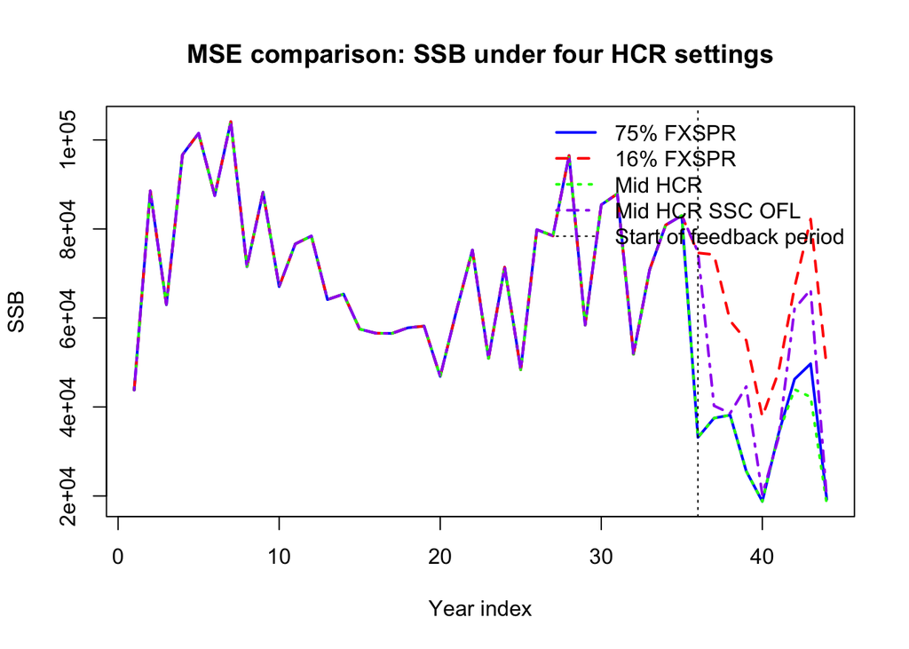

```r
plot(
  mod1$om$rep$SSB,
  type = "l",
  lwd = 2,
  col = "blue",
  xlab = "Year index",
  ylab = "SSB",
  main = "MSE comparison: SSB under four HCR settings"
)

lines(
  mod2$om$rep$SSB,
  col = "red",
  lwd = 2,
  lty = 2
)

lines(
  mod3$om$rep$SSB,
  col = "green",
  lwd = 2,
  lty = 3
)


lines(
  mod4$om$rep$SSB,
  col = "purple",
  lwd = 2,
  lty = 4
)

abline(v = first_free_year, lty = 3)

legend(
  "topright",
  legend = c("75% FXSPR", "16% FXSPR", "Mid HCR", "Mid HCR SSC OFL", "Start of feedback period"),
  col = c("blue", "red", "green", "purple", "black"),
  lty = c(1, 2, 3, 4, 3),
  lwd = c(2, 2, 2, 2, 1),
  bty = "n"
)
```

I probably need to change some numbers because the start of the feedback period should be right after the assessment? Or include assessment projections?